# Using rtry for general data pre-processing

## Filter outliers based on error risk (`ErrorRisk`)

The final example for the filtering process would be to remove the outliers. To do so, filter the data with `ErrorRisk` larger than or equal to 4.0. With this in mind, the `rtry_explore()` function is used to explore the data as reference.

```r
# Group the input data based on DataID, DataName, TraitID, TraitName and ErrorRisk
# Then sort the output by ErrorRisk using the sortBy argument
tmp_unfiltered <- rtry_explore(workdata, DataID, DataName, TraitID, TraitName, ErrorRisk, sortBy = ErrorRisk)
```

```r
## dim:   50 6
```

From the exploration result, it can be seen that there are a few outliers (with `ErrorRisk` larger than 4.0 in this case). It can also be observed that for those `ErrorRisk` equals NA, are data that contains the georeference information and exposition of the observation. These are the value where `ErrorRisk` does not apply and should be kept.

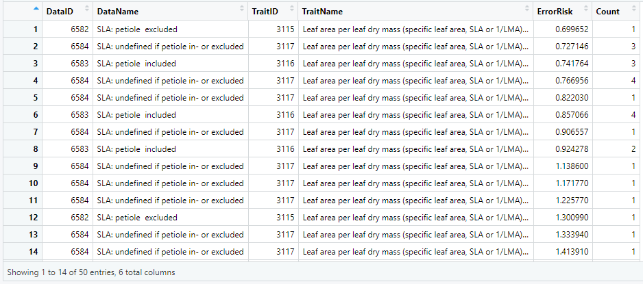

workflow_general_explore_aux_unfiltered_outliers

After understanding what data to be filtered, use the `rtry_filter()` function to perform the data removal:

```r
# Criteria
# 1. ErrorRisk larger than or equal to 4
workdata <- rtry_filter(workdata, ErrorRisk >= 4)
```

```r
## dim:   139 17
```

Always double check the filtered data before continuing the pre-processing.

```r
# Group the input data based on DataID, DataName, TraitID, TraitName and ErrorRisk
# Then sort the output by ErrorRisk using the sortBy argument
tmp_filtered <- rtry_explore(workdata, DataID, DataName, TraitID, TraitName, ErrorRisk, sortBy = ErrorRisk)
```

```r
## dim:   48 6
```

From the exploration result, it can be seen that the outliers (i.e. `ErrorRisk` larger than or equal to 4.0) were removed.

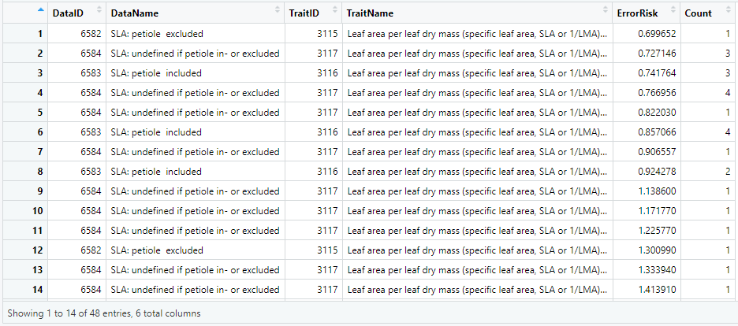

workflow_general_explore_aux_filtered_outliers

# Remove duplicates based on duplicate identifier (`OrigObsDataID`)

As of July 2019, the TRY database comprised 588 data sets from 765 data contributors (Kattge et al. [2019](https://onlinelibrary.wiley.com/doi/full/10.1111/gcb.14904) GCB). To keep track of potential duplicate entries, an unique identifier known as `OrigObsDataID` is assigned when certain observation data has previously been contributed. With the help of this `OrigObsDataID`, the `rtry` package provides a function `rtry_rm_dup()` for users to easily remove the duplicates from the data for further processing.

The `rtry_rm_dup()` takes two arguments `input` and `showOverview`, and returns a data table of the input data after removing the duplicates. Note: This function depends on the duplicate identifier `OrigObsDataID` listed in the TRY data, therefore, if the column `OrigObsDataID` has been removed, this function will not work. Also, if the imported TRY data contains restricted dataset that belongs to another dataset (i.e. having an `OrigObsDataID`), these restricted data will also be removed resulting in data loss.

To remove the duplicates from `workdata`, simply use the call the function:

```r
# Remove duplicates
workdata <- rtry_rm_dup(workdata)
```

```r
## 21 duplicates removed.
## dim:   118 17
```

Once the function is called and executed, by default the number of duplicates removed and the resulting dimension of the data will be displayed on the console as reference.

# Transform to wide table

For data management purposes, the TRY data is structured as a long table and this is what have been used so far. However, for human operators, it is more common to read and understand a dataset in a wide table format. Therefore, the `rtry` package offers the function `rtry_trans_wider()` for users to transform the long table into a wide table (i.e. increasing the number of columns and decreasing the number of rows) when needed.

The `rtry_trans_wider()` takes five arguments `input`, `names_from`, `values_from`, `values_fn` and `showOverview` to transform the original long table format of the TRY data into a wide table format. Note: This function is based on the function `tidyr::pivot_wider()`.

To ensure the long table to wide table transformation would not result in duplicate entries because of the potentially existence of multiple `ObservationID` for a single trait, the first step is to select only the traits with numerical values, and then to simply this example, only the most relevant columns will be selected.

```r
#-------------------------------------------------
# Exclude
# 1. All entries with "" in TraitID
# 2. Potential categorical traits that don't have a StdValue
# 3. Traits that have not yet been standardized in TRY
# Select the columns for transformation
# Then select the relevant columns for transformation
#-------------------------------------------------
num_traits <- rtry_select_row(workdata, complete.cases(TraitID) & complete.cases(StdValue))
num_traits <- rtry_select_col(num_traits, ObservationID, AccSpeciesID, AccSpeciesName, TraitID, TraitName, StdValue, UnitName)
```

```r
## dim:   40 17
## dim:   40 7
## col:   ObservationID AccSpeciesID AccSpeciesName TraitID TraitName StdValue UnitName
```

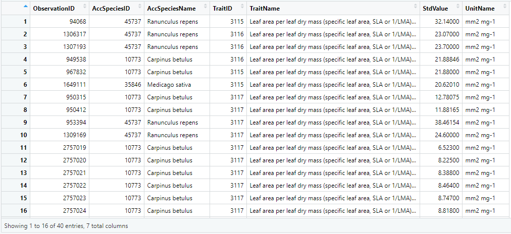

workflow_general_trans_wider_num_traits

Now that only the traits with numerical values were selected, in order to keep the auxiliary data while transforming the data from long table into wide table on traits, the auxiliary data needs to be added manually as additional columns before proceeding.

For demonstration purpose, the latitude and longitude information will be added to the input data to create a georeferenced traits before proceeding. To extract the unique values of the auxiliary data and the corresponding `ObservationID`, use the `rtry_select_aux()` function.

```r
# Extract the unique value of latitude data and the corresponding ObservationID
workdata_lat <- rtry_select_aux(workdata, Latitude)

# Extract the unique value of longitude data and the corresponding ObservationID
workdata_lon <- rtry_select_aux(workdata, Longitude)
```

```r
## dim:   23 2
## col:   ObservationID Latitude
## dim:   22 2
## col:   ObservationID Longitude
```

Next, add the extracted latitude and longitude information to the traits. To do so, make use of the `ObservationID` in both the trait records and the extracted auxiliary data to merge the data frames. And in order to keep all the trait records, a left join should be used. This can be done using the `rtry_merge_col()` function provided in the `rtry` package.

```r
# To merge the extracted auxiliary data with the numerical traits
# Merge the relevant data frames based on the ObservationID using rtry_merge_col (left join)
num_traits_georef <- rtry_merge_col(num_traits, workdata_lat)
num_traits_georef <- rtry_merge_col(num_traits_georef, workdata_lon)
```

```r
## dim:   40 8
## col:   ObservationID AccSpeciesID AccSpeciesName TraitID TraitName StdValue UnitName Latitude
## dim:   40 9
## col:   ObservationID AccSpeciesID AccSpeciesName TraitID TraitName StdValue UnitName Latitude Longitude
```

Use either `head()` or `View()` function to view the merge data. It can be seen that the extracted latitude and longitude information were added to the right of the numerical traits.

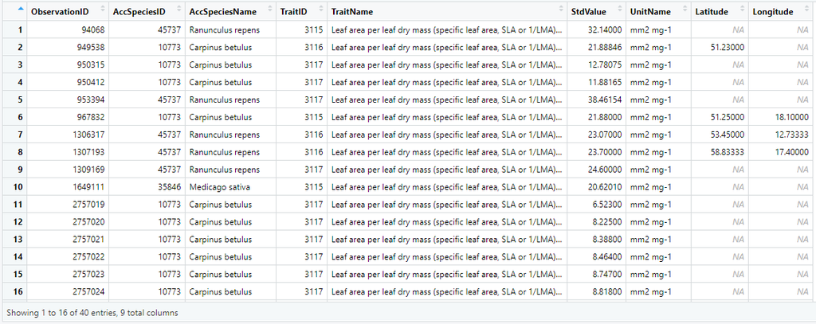

workflow_general_trans_wider_num_traits_georef

Once the trait records and the necessary auxiliary data were prepared, the transformation is performed on the `TraitID`, `TraitName` and `UnitName`, meaning to get the name of these three columns as part of the name of the output column (`names_from`), and then use the `StdValue` as the cell values (`values_from`). Also, the mean function is to be applied to each cell in the output (`values_fn`). To do so, use the following command:

```r
# Perform wide table transformation on TraitID, TraitName and UnitName
# With cell values to be the mean values calculated for StdValue
num_traits_georef_wider <- rtry_trans_wider(num_traits_georef, names_from = c(TraitID, TraitName, UnitName), values_from = c(StdValue), values_fn = list(StdValue = mean))
```

```r
# dim:   40 8
```

Immediately, it can be seen that the columns new columns `TraitID`, `TraitName` and `UnitName` were “transformed” into new columns, which were named for example “3115_Leaf area per leaf dry mass (specific leaf area, SLA or 1/LMA): petiole excluded_mm2 mg-1”.

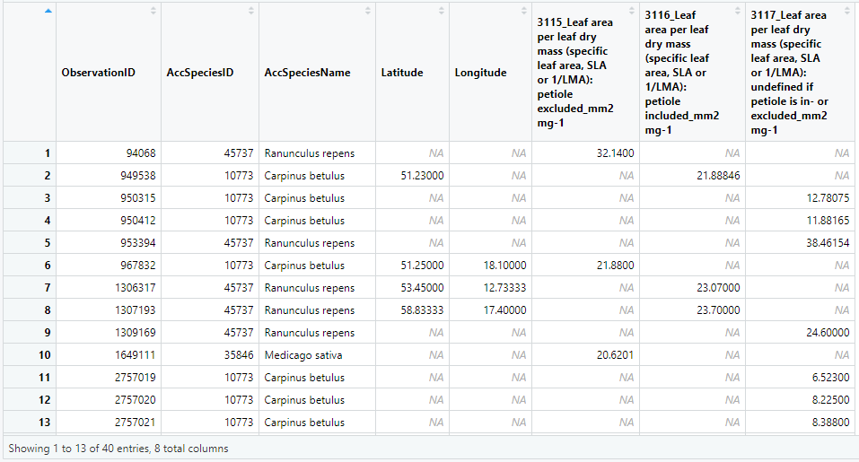

workflow_general_trans_wider_traits

# Export pre-processed TRY data

The `rtry_export()` takes four arguments `data`, `output`, `quote` and `encoding` for users to export the pre-processed data as a CSV file. Note: If the specified output directory does not exist, it will be created automatically.

```r
# Export the data into a CSV file
rtry_export(num_traits_georef_wider, "output/workdata_wider_traits.csv")
```

```r
## New directory created at: output
## File saved at: output/workdata_wider_traits.csv
```